# RNA-seq-workflow

ljm

2018/4/13

## 1 ~ 3. 从bam文件

### 使用bam文件

从airway包中找到extdata数据位置： 这里都是比对完的sam转换后的bam：

```r
library(magrittr)

library("airway")
indir <- system.file("extdata", package="airway", mustWork=TRUE)
list.files(indir)
```

```
##  [1] "GSE52778_series_matrix.txt"
##  [2] "Homo_sapiens.GRCh37.75_subset.gtf"
##  [3] "sample_table.csv"
##  [4] "SraRunInfo_SRP033351.csv"
##  [5] "SRR1039508_subset.bam"
##  [6] "SRR1039509_subset.bam"
##  [7] "SRR1039512_subset.bam"
##  [8] "SRR1039513_subset.bam"
##  [9] "SRR1039516_subset.bam"
## [10] "SRR1039517_subset.bam"
## [11] "SRR1039520_subset.bam"
## [12] "SRR1039521_subset.bam"
```

读入样本信息csv文件，这里的bam文件都是subset用来测试：

```r
csvfile <- file.path(indir, "sample_table.csv")
sampleTable <- read.csv(csvfile, row.names = 1)
sampleTable
```

```
##            SampleName    cell   dex albut        Run avgLength Experiment
## SRR1039508 GSM1275862  N61311 untrt untrt SRR1039508       126  SRX384345
## SRR1039509 GSM1275863  N61311   trt untrt SRR1039509       126  SRX384346
## SRR1039512 GSM1275866 N052611 untrt untrt SRR1039512       126  SRX384349
## SRR1039513 GSM1275867 N052611   trt untrt SRR1039513        87  SRX384350
## SRR1039516 GSM1275870 N080611 untrt untrt SRR1039516       120  SRX384353
## SRR1039517 GSM1275871 N080611   trt untrt SRR1039517       126  SRX384354
## SRR1039520 GSM1275874 N061011 untrt untrt SRR1039520       101  SRX384357
## SRR1039521 GSM1275875 N061011   trt untrt SRR1039521        98  SRX384358
##               Sample    BioSample
## SRR1039508 SRS508568 SAMN02422669
## SRR1039509 SRS508567 SAMN02422675
## SRR1039512 SRS508571 SAMN02422678
## SRR1039513 SRS508572 SAMN02422670
## SRR1039516 SRS508575 SAMN02422682
## SRR1039517 SRS508576 SAMN02422673
## SRR1039520 SRS508579 SAMN02422683
## SRR1039521 SRS508580 SAMN02422677
```

确定csv文件中的所有样本bam都存在：

```r
filenames <- file.path(indir, paste0(sampleTable$Run, "_subset.bam"))
file.exists(filenames)
```

```
## [1] TRUE TRUE TRUE TRUE TRUE TRUE TRUE TRUE
```

使用Rsamtools建立到bam文件的reference; 指定处理bam文件时一次处理2M reads:

```r
library("Rsamtools")
bamfiles <- BamFileList(filenames, yieldSize=2000000)
```

BamFileList()创建一个列表，每个元素是一个BamFile实例: 查看BamFile实例的信息，确定最开始比对生成sam时候染色体标记为chr1 or 1：

```r
seqinfo(bamfiles[8])
```

```
## Seqinfo object with 84 sequences from an unspecified genome:
##   seqnames   seqlengths isCircular genome
##   1           249250621       <NA>   <NA>
##   10          135534747       <NA>   <NA>
##   11          135006516       <NA>   <NA>
##   12          133851895       <NA>   <NA>
##   13          115169878       <NA>   <NA>
##   ...               ...        ...    ...
##   GL000210.1      27682       <NA>   <NA>
##   GL000231.1      27386       <NA>   <NA>
##   GL000229.1      19913       <NA>   <NA>
##   GL000226.1      15008       <NA>   <NA>
##   GL000207.1       4262       <NA>   <NA>
```

### 定义gene models

使用gtf文件,创建TxDb对象： TxDb对象包含转录本注释信息，对于ensembl可以从gtf/gff创建，对于ucsc直接从TxDb.Hsapiens.UCSC.hg19.knownGene 获得。

```r
library("GenomicFeatures")
gtffile <- file.path(indir,"Homo_sapiens.GRCh37.75_subset.gtf")
txdb <- makeTxDbFromGFF(gtffile, format = "gtf", circ_seqs = character())
txdb
```

```
## TxDb object:
## # Db type: TxDb
## # Supporting package: GenomicFeatures
## # Data source: /home/ljm/R/x86_64-redhat-linux-gnu-library/3.4/airway/extdata/Homo_sapiens.GRCh37.75_subset.gtf
## # Organism: NA
## # Taxonomy ID: NA
## # miRBase build ID: NA
## # Genome: NA
## # transcript_nrow: 65
## # exon_nrow: 279
## # cds_nrow: 158
## # Db created by: GenomicFeatures package from Bioconductor
## # Creation time: 2018-04-19 16:40:16 +0800 (Thu, 19 Apr 2018)
## # GenomicFeatures version at creation time: 1.30.3
## # RSQLite version at creation time: 2.1.0
## # DBSCHEMAVERSION: 1.2
```

从TxDb中按照gene提取转录信息，返回一个GRangesList:

Produce a GRangesList of all the exons grouped by gene. Each element of the list is a GRanges object of the exons for a gene.

```r
ebg <- exonsBy(txdb, by="gene")
ebg
```

```
## GRangesList object of length 20:
## $ENSG00000009724
## GRanges object with 18 ranges and 2 metadata columns:
##        seqnames               ranges strand |   exon_id       exon_name
##           <Rle>            <IRanges>  <Rle> | <integer>     <character>
##    [1]        1 [11086580, 11087705]      - |        98 ENSE00000818830
##    [2]        1 [11090233, 11090307]      - |        99 ENSE00000472123
##    [3]        1 [11090805, 11090939]      - |       100 ENSE00000743084
##    [4]        1 [11094885, 11094963]      - |       101 ENSE00000743085
##    [5]        1 [11097750, 11097868]      - |       102 ENSE00003482788
##    ...      ...                  ...    ... .       ...             ...
##   [14]        1 [11106948, 11107176]      - |       111 ENSE00003467404
##   [15]        1 [11106948, 11107176]      - |       112 ENSE00003489217
##   [16]        1 [11107260, 11107280]      - |       113 ENSE00001833377
##   [17]        1 [11107260, 11107284]      - |       114 ENSE00001472289
##   [18]        1 [11107260, 11107290]      - |       115 ENSE00001881401
##
## ...
## <19 more elements>
## -------
## seqinfo: 1 sequence from an unspecified genome; no seqlengths
```

```r
# metadata(ebg) %>% str
```

### 计算gene count

如果需要多线程：

library(“BiocParallel”) browseVignettes(“BiocParallel”)

创建SummarizedExperiment / se对象： 根据bam信息和gene models计算出count,包括在se中

```r
library("GenomicAlignments")

se <- summarizeOverlaps(features=ebg, reads=bamfiles,
                        mode="Union",
                        singleEnd=FALSE,
                        ignore.strand=TRUE,
                        fragments=TRUE )
```

__SummarizedExperiment object__包含以下几个部分: assay：count matrix rowRanges : 每个基因信息，用来计数的 GRangesList (ebg) colData: sample info (需要手动补充)

```r
se
```

```
## class: RangedSummarizedExperiment
## dim: 20 8
## metadata(0):
## assays(1): counts
## rownames(20): ENSG00000009724 ENSG00000116649 ... ENSG00000271794
##   ENSG00000271895
## rowData names(0):
## colnames(8): SRR1039508_subset.bam SRR1039509_subset.bam ...
##   SRR1039520_subset.bam SRR1039521_subset.bam
## colData names(0):
```

```r
assay(se) %>% head(2)
```

```
##                 SRR1039508_subset.bam SRR1039509_subset.bam
## ENSG00000009724                    38                    28
## ENSG00000116649                  1004                  1255
##                 SRR1039512_subset.bam SRR1039513_subset.bam
## ENSG00000009724                    66                    24
## ENSG00000116649                  1122                  1313
##                 SRR1039516_subset.bam SRR1039517_subset.bam
## ENSG00000009724                    42                    41
## ENSG00000116649                  1100                  1879
##                 SRR1039520_subset.bam SRR1039521_subset.bam
## ENSG00000009724                    47                    36
## ENSG00000116649                   745                  1536
```

```r
rowRanges(se) %>% identical(ebg)
```

```
## [1] TRUE
```

手动补充colData, 用csv文件中的样本信息：

```r
colData(se)
```

```
## DataFrame with 8 rows and 0 columns
```

```r
colData(se)<- DataFrame(sampleTable)
colData(se) %>% head(2)
```

```
## DataFrame with 2 rows and 9 columns
##            SampleName     cell      dex    albut        Run avgLength
##              <factor> <factor> <factor> <factor>   <factor> <integer>
## SRR1039508 GSM1275862   N61311    untrt    untrt SRR1039508       126
## SRR1039509 GSM1275863   N61311      trt    untrt SRR1039509       126
##            Experiment    Sample    BioSample
##              <factor>  <factor>     <factor>
## SRR1039508  SRX384345 SRS508568 SAMN02422669
## SRR1039509  SRX384346 SRS508567 SAMN02422675
```

对SummarizedExperiment手动设置colData之后，count matrix中的列名会自动依次变化成colData的行名! 且顺序必须一致！：

```r
assay(se) %>% colnames
```

```
## [1] "SRR1039508" "SRR1039509" "SRR1039512" "SRR1039513" "SRR1039516"
## [6] "SRR1039517" "SRR1039520" "SRR1039521"
```

## 4. DESeq2 中的dds对象

DESeq2中的 DESeqDataSet/dds 类就是基于SummarizedExperiment/se类； 不同点: dds中的assay通过函数counts()获得; dds 包含design formula.

se或者dds中提取colData中的列名(colData name)可以直接用$调用:

```r
se$dex
```

```
## [1] untrt trt   untrt trt   untrt trt   untrt trt
## Levels: trt untrt
```

```r
se$cell
```

```
## [1] N61311  N61311  N052611 N052611 N080611 N080611 N061011 N061011
## Levels: N052611 N061011 N080611 N61311
```

### 4.1 从SummarizedExperiment开始

使用 **包含全部基因** 的完整的se:

```r
data("airway")
se <- airway
assay(se) %>% dim
```

```
## [1] 64102     8
```

重新指定factor的level的顺序：

```r
se$dex %<>% relevel("untrt")
se$dex
```

```
## [1] untrt trt   untrt trt   untrt trt   untrt trt
## Levels: untrt trt
```

查看reads数(M)

```r
round(colSums(assay(se))/ 1e6, 2)
```

```
## SRR1039508 SRR1039509 SRR1039512 SRR1039513 SRR1039516 SRR1039517
##      20.64      18.81      25.35      15.16      24.45      30.82
## SRR1039520 SRR1039521
##      19.13      21.16
```

```r
colData(se) %>% head(2)
```

```
## DataFrame with 2 rows and 9 columns
##            SampleName     cell      dex    albut        Run avgLength
##              <factor> <factor> <factor> <factor>   <factor> <integer>
## SRR1039508 GSM1275862   N61311    untrt    untrt SRR1039508       126
## SRR1039509 GSM1275863   N61311      trt    untrt SRR1039509       126
##            Experiment    Sample    BioSample
##              <factor>  <factor>     <factor>
## SRR1039508  SRX384345 SRS508568 SAMN02422669
## SRR1039509  SRX384346 SRS508567 SAMN02422675
```

从se新建dds,并且指定design formula:

```r
library(DESeq2)
dds <- DESeqDataSet(se, design = ~ cell + dex)
```

### 4.2 从count matrices开始

如果使用的是count matrix，新建dds：

```r
m_count <- assay(se)
m_coldata <- colData(se)
ddsMat <- DESeqDataSetFromMatrix(countData = m_count,
                                 colData = m_coldata,
                                 design = ~ cell + dex)
```

## 5.样本关系分析及可视化：

**样本之间关系分析，例如聚类，PCA等，需要先对样本count数先标准化再可视化；而统计推断需要用raw counts!**

### 5.1 过滤数据

```r
nrow(dds)
```

```
## [1] 64102
```

```r
idx <- rowSums(counts(dds)) > 1
dds <- dds[idx,]
nrow(dds)
```

```
## [1] 29391
```

### 5.1.1 rlog or VST transfortmation:

聚类，PCA等方法适合的数据，各个基因的均值可以差异很大，但是不同基因的方差应该基本一致；但是RNA-seq的raw count基本服从poisson分布，方差随着均值增大而增大，如果直接对counts or normalized counts(TPM等消除测序深度的标准化方法)做聚类或者PCA，高表达基因 将会贡献较大的方差。消除方差不一致的一种方法可以是log2(normalized counts + 1)，但是+1又会使得的低表达量的基因的方差变大，这使得低表达值的基因又贡献较大方差。

生成**cts**模拟1000个基因，100个样本的count matrix：

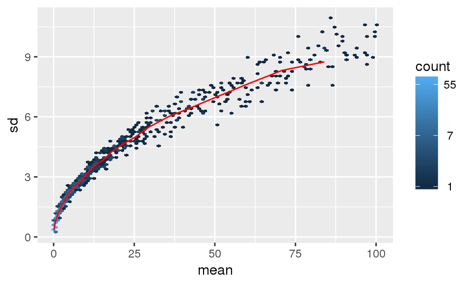

```r
lambda <- 10^seq(from = -1, to = 2, length = 1000)
cts <- matrix(rpois(1000*100, lambda), ncol = 100)
library(vsn)
meanSdPlot(cts, ranks = FALSE, bin=80)
```

log2(count+1)变换：

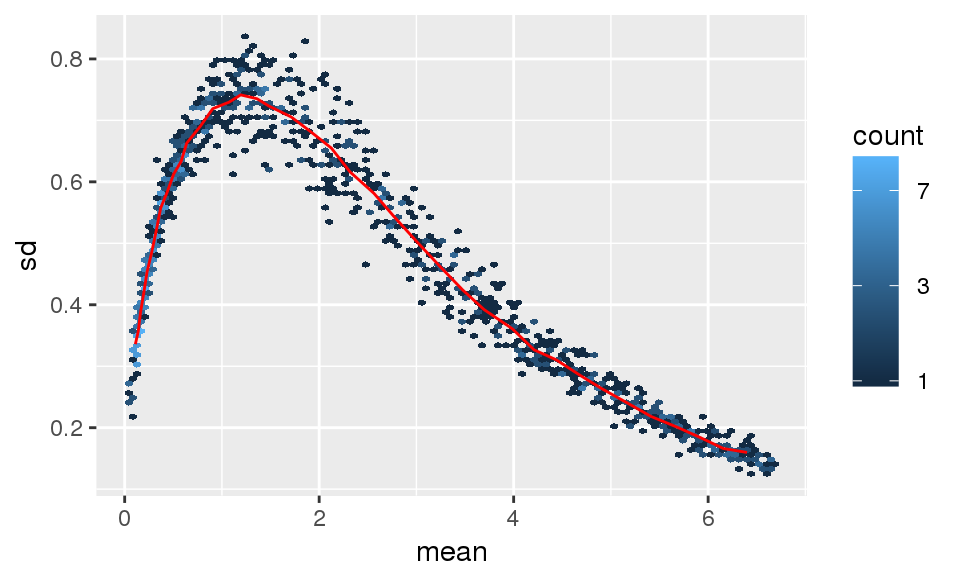

```r
log.cts.one <- log2(cts + 1)
meanSdPlot(log.cts.one, ranks = FALSE, bin = 80)
```

**VST, rlog transformation**:

对于高count的基因，这两种transformation得到类似log2转换的结果，对于低count的基因，使得方差接近均值。 样本较少的时候(n<30), 更加适合用rlog； 样本较多的时候， 更加适合VST。 这两种transformation都是用于方差一致的分析，而**不是用于差异分析！**

对cts测试数据分别做vst, rlog transformation:

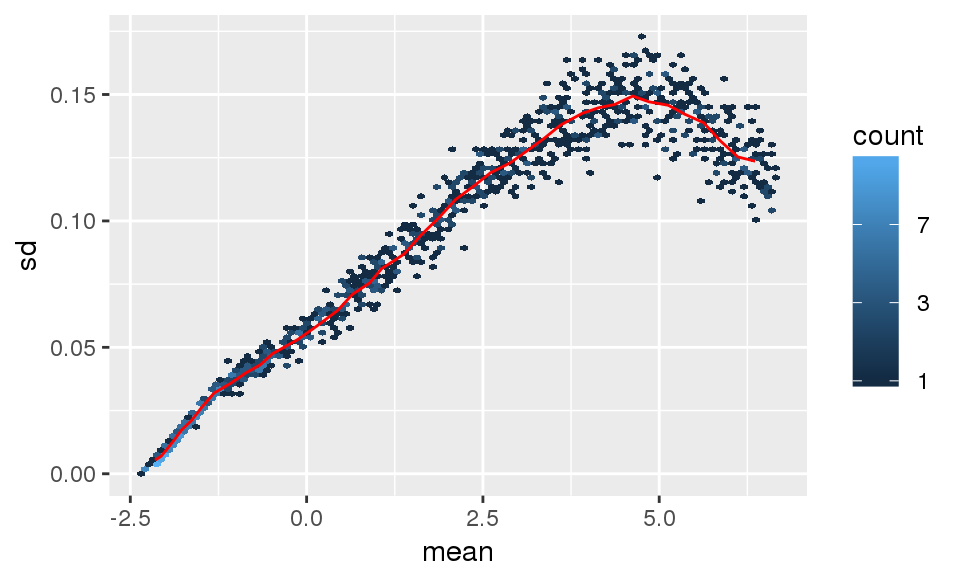

```r
cts_r <- rlog(cts, blind = FALSE)
meanSdPlot(cts_r, ranks = FALSE, bin =80)
```

对于上面的rlog transformation,sd显著降低了(mean范围也发生改变)

做vst transformation: 因为cts测试数据只有1000个基因，所以没有使用vst().

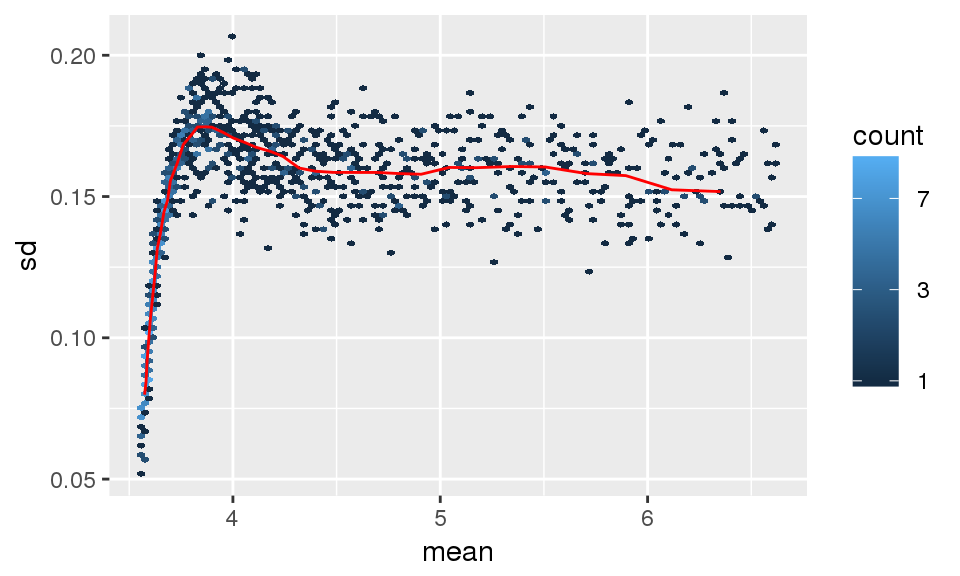

```r
cts_v <- varianceStabilizingTransformation(cts, blind = FALSE)
meanSdPlot(cts_v, ranks = FALSE, bin = 80)
```

对于上面的vst transformation, sd显著降低了(mean范围也改变了)。

### 5.2 样本之间比较

回到真实数据dds，比较log2, rlog, vst 变换： 比较第4，5个样本

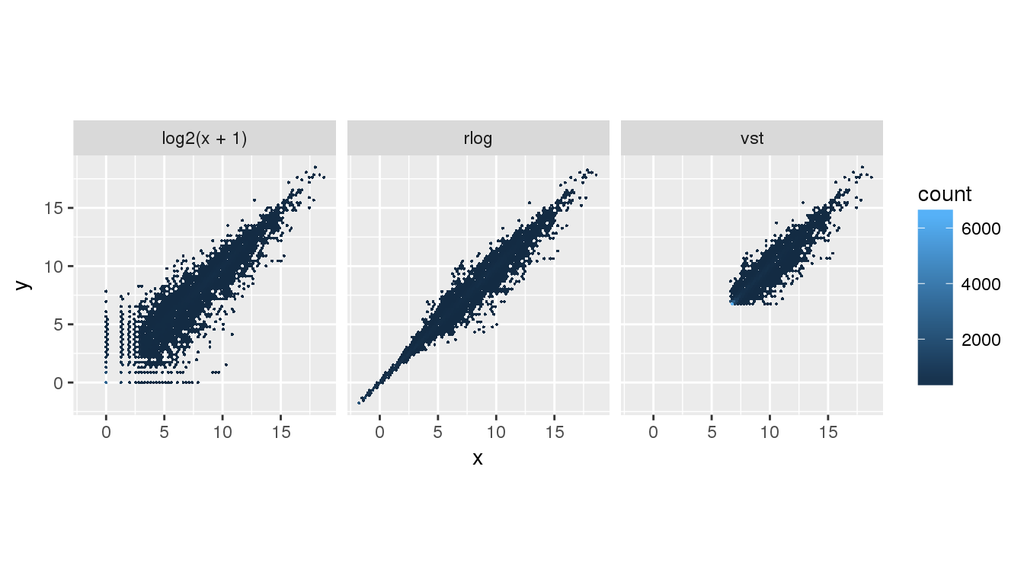

```r
rld <- rlog(dds, blind = FALSE)
vsd <- vst(dds, blind = FALSE)

library("dplyr")
library("ggplot2")

dds <- estimateSizeFactors(dds)

df <- bind_rows(
  as_data_frame(log2(counts(dds, normalized=TRUE)[, 4:5]+1)) %>%
    mutate(transformation = "log2(x + 1)"),
  as_data_frame(assay(rld)[, 4:5]) %>% mutate(transformation = "rlog"),
  as_data_frame(assay(vsd)[, 4:5]) %>% mutate(transformation = "vst"))

colnames(df)[1:2] <- c("x", "y")

ggplot(df, aes(x, y)) +
  geom_hex(bins = 80) +
  coord_fixed(ratio =1) +
  facet_grid( . ~ transformation)
```

上图中，这两个样本相互比较，在低表达的基因中，log2放大了基因间的差异，而rlog，vst显著压缩了差异。VST还将小数值向上偏移。 聚类，PCA中样本的距离就是基于散点对y=x这条线的偏移来计算的。

### 5.3 样本之间距离

Heatmap of sample-to-sample distances using the rlog-transformed values. 计算样本之间距离，并且生成距离矩阵：

```r
sampleDists <- dist(t(assay(rld)))
sampleDists
```

```
##            SRR1039508 SRR1039509 SRR1039512 SRR1039513 SRR1039516
## SRR1039509   45.69859
## SRR1039512   39.25239   54.90828
## SRR1039513   62.63201   44.52740   48.72579
## SRR1039516   44.50557   59.06364   43.57856   63.74275
## SRR1039517   64.49410   51.44882   59.22962   49.87992   47.48200
## SRR1039520   39.57693   57.46259   36.74434   58.49014   46.40786
## SRR1039521   63.36124   45.05732   57.87616   36.49484   65.54600
##            SRR1039517 SRR1039520
## SRR1039509
## SRR1039512
## SRR1039513
## SRR1039516
## SRR1039517
## SRR1039520   63.59942
## SRR1039521   52.31695   50.13430
```

根据样本之间的距离填充颜色：

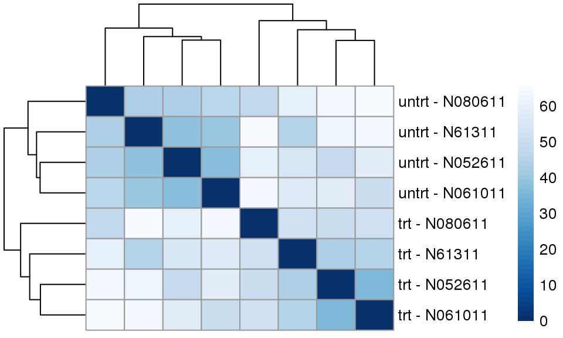

```r
library("pheatmap")
library("RColorBrewer")

sampleDistMatrix <- as.matrix( sampleDists )
rownames(sampleDistMatrix) <- paste( rld$dex, rld$cell, sep = " - " )
colnames(sampleDistMatrix) <- NULL
colors <- colorRampPalette( rev(brewer.pal(9, "Blues")) )(50)
pheatmap(sampleDistMatrix,
         clustering_distance_rows = sampleDists,
         clustering_distance_cols = sampleDists,
         col = colors)
```

另外一种计算样本距离的方法：poisson distance, 考虑到了count数的内部差异，直接用raw counts计算距离，不用任何normalization.

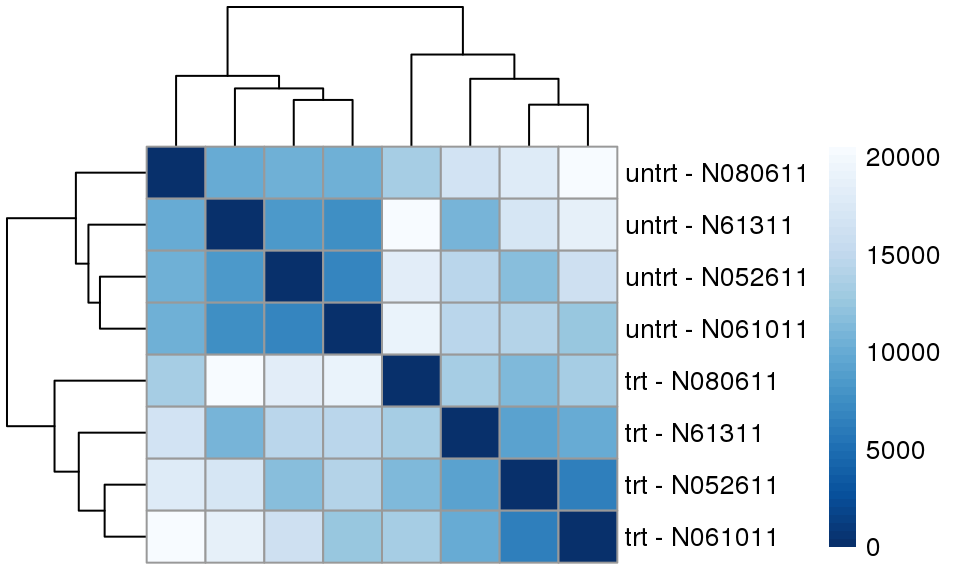

```r
library("PoiClaClu")
poisd <- PoissonDistance(t(counts(dds)))

samplePoisDistMatrix <- as.matrix( poisd$dd )
rownames(samplePoisDistMatrix) <- paste( rld$dex, rld$cell, sep=" - " )
colnames(samplePoisDistMatrix) <- NULL
pheatmap(samplePoisDistMatrix,
         clustering_distance_rows = poisd$dd,
         clustering_distance_cols = poisd$dd,
         col = colors)
```

以上两种方法，衡量距离的尺度不同。

## 6 差异分析

从SE开始，指定design创建dds;过滤； DESeq()会完成计算sizeFactor, 评估每个基因值的分布，拟合线性模型等一系列操作; DESeq() 返回一个dds，包含所有计算出来的参数， 例如sizeFactor写到了colData中：

```r
se <- airway
se$dex %<>% relevel("untrt")
dds <- DESeqDataSet(se, design = ~ cell + dex)
dds <- dds[rowSums(counts(dds)) > 1, ]
dds <- DESeq(dds)
```

results()不指定变量的话，默认提取design formula中最后一个变量， 并且使用这个变量的最后一个level比上第一个level: 下面写法在这里意义相同：

```r
res <- results(dds)
res <- results(dds, contrast=c("dex","trt","untrt"))
```

返回的res是一个DataFrame，这是一个S4对象，查看列meta信息：

```r
mcols(res, use.names = TRUE)
```

```
## DataFrame with 6 rows and 2 columns
##                        type                               description
##                 <character>                               <character>
## baseMean       intermediate mean of normalized counts for all samples
## log2FoldChange      results  log2 fold change (MLE): dex trt vs untrt
## lfcSE               results          standard error: dex trt vs untrt
## stat                results          Wald statistic: dex trt vs untrt
## pvalue              results       Wald test p-value: dex trt vs untrt
## padj                results                      BH adjusted p-values
```

baseMean: 根据sizeFactor对count标准化，所以依赖所有样本.

结果对象res中，包含**所有基因**的情况，满足lfcThreshold的基因才会做p值校验; 默认FDR < 10%(alpha = 0.1):

```r
res2 <- results(dds, contrast=c("dex","trt","untrt"),
                alpha = 0.05,
                lfcThreshold = 1)
summary(res2)
```

```
##
## out of 29391 with nonzero total read count
## adjusted p-value < 0.05
## LFC > 0 (up)     : 142, 0.48%
## LFC < 0 (down)   : 80, 0.27%
## outliers [1]     : 0, 0%
## low counts [2]   : 9687, 33%
## (mean count < 3)
## [1] see 'cooksCutoff' argument of ?results
## [2] see 'independentFiltering' argument of ?results
```

除了用result()中设置alpha, lfcThreshold等参数结合summary()查看差异基因个数， 还可以从res中根据**列名**直接提取子集：

```r
subset(res, padj < 0.05) %>%
  subset(log2FoldChange > 1) %>%
  subset(baseMean > 3) -> tem
tem[order(tem$log2FoldChange), ]
```

```
## log2 fold change (MLE): dex trt vs untrt
## Wald test p-value: dex trt vs untrt
## DataFrame with 528 rows and 6 columns
##                   baseMean log2FoldChange      lfcSE      stat
##                  <numeric>      <numeric>  <numeric> <numeric>
## ENSG00000074527 4090.85688       1.004021 0.16448303  6.104102
## ENSG00000173221 1983.22156       1.004287 0.09817957 10.229080
## ENSG00000175946   46.18754       1.004610 0.28773154  3.491483
## ENSG00000221968 1863.01473       1.004745 0.10944727  9.180176
## ENSG00000003987   25.50432       1.004805 0.37269374  2.696061
## ...                    ...            ...        ...       ...
## ENSG00000127954 286.384119       5.207160  0.4930828 10.560419
## ENSG00000132518   5.654654       5.885113  1.3241367  4.444491
## ENSG00000250978  56.318194       6.327393  0.6778153  9.334981
## ENSG00000109906 385.071029       7.352628  0.5363902 13.707610
## ENSG00000179593  67.243048       9.505972  1.0545111  9.014578
##                       pvalue         padj
##                    <numeric>    <numeric>
## ENSG00000074527 1.033801e-09 2.274109e-08
## ENSG00000173221 1.469086e-24 1.428905e-22
## ENSG00000175946 4.803462e-04 3.527898e-03
## ENSG00000221968 4.303858e-20 2.922401e-18
## ENSG00000003987 7.016477e-03 3.454295e-02
## ...                      ...          ...
## ENSG00000127954 4.546302e-26 5.049763e-24
## ENSG00000132518 8.810031e-06 1.000175e-04
## ENSG00000250978 1.010098e-20 7.212582e-19
## ENSG00000109906 9.141988e-43 2.253437e-40
## ENSG00000179593 1.976299e-19 1.252166e-17
```

res对象中都是含有所有的基因的baseMean，但是根据lfcThreshold, alpha产生pvalue,padj, 不满足lfcThreshold的基因pvalue,padj = 1或NA：

```r
resLFC1 <- results(dds, lfcThreshold = 1, alpha = 0.1)
resLFC2 <- results(dds, lfcThreshold = 2, alpha = 0.01)
resLFC1$log2FoldChange %>% identical(resLFC2$log2FoldChange)
```

```
## [1] TRUE
```

```r
resLFC1$padj %>% identical(resLFC2$padj)
```

```
## [1] FALSE
```

## 7. 对结果作图

### 7.1 对单个基因作图

对单个基因，plotCounts()画图： Normalized counts for a single gene over treatment group.

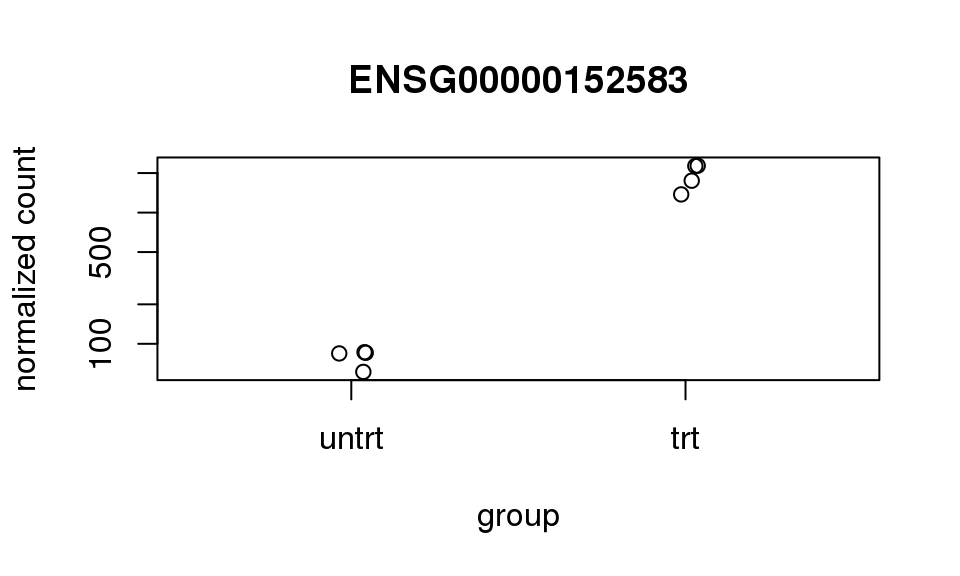

```r
topGene <- rownames(res)[which.min(res$padj)]
plotCounts(dds, gene = topGene, intgroup=c("dex"))
```

```r
plotCounts(dds, gene = topGene, intgroup = c("dex", "cell"),
           returnData = TRUE)
```

```
##                 count   dex    cell
## SRR1039508   61.06772 untrt  N61311
## SRR1039509 2276.86214   trt  N61311
## SRR1039512   84.43486 untrt N052611
## SRR1039513 1749.61320   trt N052611
## SRR1039516   85.41333 untrt N080611
## SRR1039517 1375.73220   trt N080611
## SRR1039520   86.29695 untrt N061011
## SRR1039521 2264.09778   trt N061011
```

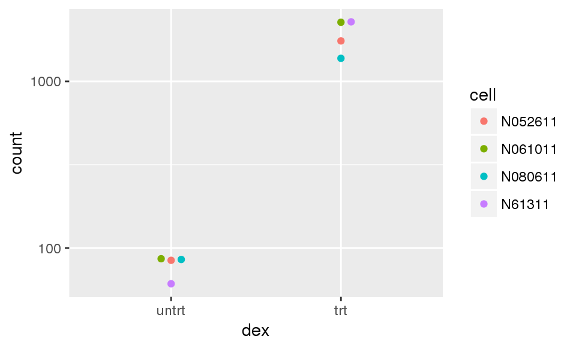

```r
library("ggbeeswarm")
geneCounts <- plotCounts(dds, gene = topGene, intgroup = c("dex","cell"),
                         returnData = TRUE)
ggplot(geneCounts, aes(x = dex, y = count, color = cell)) +
  scale_y_log10() +  geom_beeswarm(cex = 3)
```

### 7.2 MA plot

MA-plot对于1,2两个组的相同的基因: M：logG1 - logG2 = log(G1/G2) A: (logG1 + logG2)/2 DESeq采用贝叶斯方法缩短lfc，通过lfcShrink():

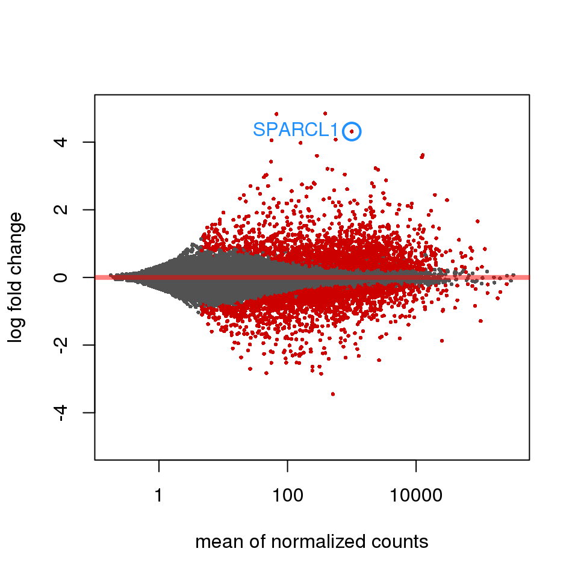

```r
res.sh <- lfcShrink(dds, contrast = c("dex","trt","untrt"), res = res)
# res中包含了contrast信息，还需要指定？

plotMA(res.sh, ylim = c(-5,5))
topGene <- rownames(res)[which.min(res$padj)] # gene symbol:"SPARCL1"
with(res.sh[topGene, ], {
  points(baseMean, log2FoldChange, col="dodgerblue", cex=2, lwd=2)
  text(baseMean, log2FoldChange, "SPARCL1", pos=2, col="dodgerblue")
})
```

P值的分布：

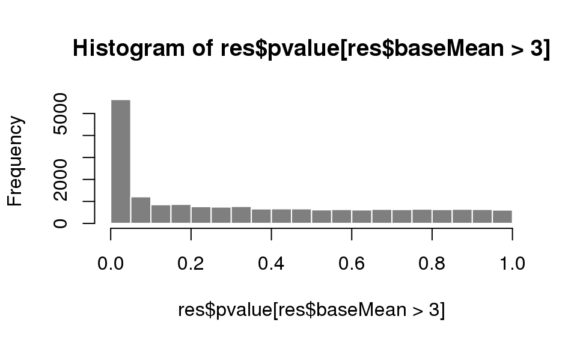

```r
hist(res$pvalue[res$baseMean > 3], breaks = 0:20/20,
     col = "grey50", border = "white")
```

### 7.3 Gene Clustering

Gene Clustering衡量样本之间距离，基因之间距离，需要对poisson分布的方差进行校正，所以用rlog transform 之后的值：

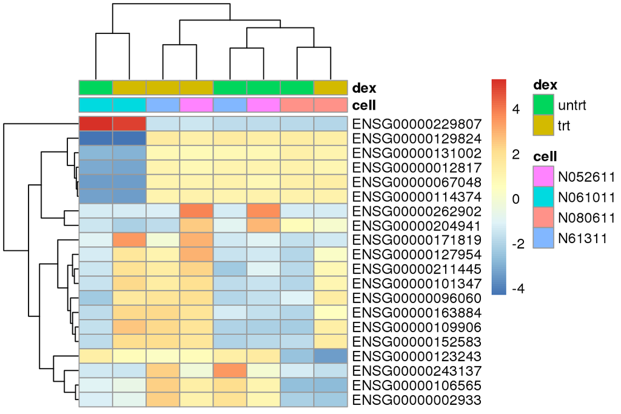

```r
library("genefilter")
topVarGenes <- head(order(rowVars(assay(rld)), decreasing = TRUE), 20)

mat  <- assay(rld)[ topVarGenes, ]
mat  <- mat - rowMeans(mat) # scale rows
anno <- as.data.frame(colData(rld)[, c("cell","dex")])
pheatmap(mat, annotation_col = anno, show_colnames = FALSE)
```

### 7.4 Independent filtering

对于所有baseMean>0基因，根据baseMean分成指定概率的quantile; (quantile()是根据min,max的差值计算分位数，与ntile()根据rank不同！); 各个分位数中间，显著的基因所占的比例：

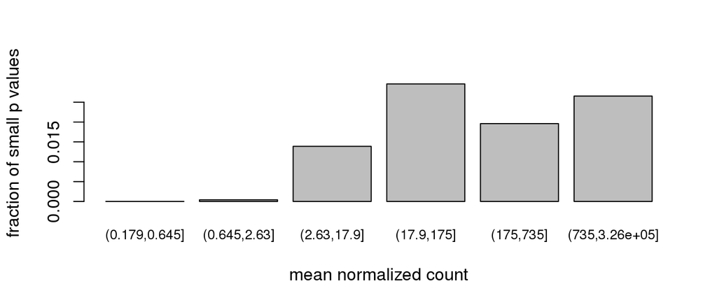

```r
resLFC1 <- results(dds, lfcThreshold = 1, alpha = 0.1)

qs <- quantile(resLFC1$baseMean[resLFC1$baseMean > 0], 0:6/6)
bins <- cut(resLFC1$baseMean, qs)
# levels(bins) <- paste0("~", round(signif((qs[-1] + qs[-length(qs)])/2, 2)))
fractionSig <- tapply(resLFC1$pvalue, bins, function(p)
                          mean(p < .05, na.rm = TRUE))
barplot(fractionSig, xlab = "mean normalized count",
                     ylab = "fraction of small p values",cex.names = 0.8)
```

从MA-plot也看出，count低的基因，很少有显著的Pvalue, 但是在多重检验的时候，这些基因影响检验效力，去除低表达的基因，可以增加效力。 DESeq2根据alpha,自动完成independent filtering.

## 8 结果注释和导出

### 8.1 向result增加信息

向result中增加一列注释信息：

```r
library("AnnotationDbi")
library("org.Hs.eg.db")

resLFC1 <- results(dds, lfcThreshold = 1, alpha = 0.01)
resLFC1$symbol <- mapIds(org.Hs.eg.db,
                         keys=row.names(res),
                         column="SYMBOL",
                         keytype="ENSEMBL",
                         multiVals="first")
resLFC1 %>% summary
```

```
##
## out of 29391 with nonzero total read count
## adjusted p-value < 0.01
## LFC > 0 (up)     : 124, 0.42%
## LFC < 0 (down)   : 65, 0.22%
## outliers [1]     : 0, 0%
## low counts [2]   : 9687, 33%
## (mean count < 3)
## [1] see 'cooksCutoff' argument of ?results
## [2] see 'independentFiltering' argument of ?results
```

result结果是DataFrame对象，可以通过as.data.frame()转换成data frame:

```r
subset(resLFC1, padj < 0.01) %>% as.data.frame() %>% head
```

```
##                  baseMean log2FoldChange     lfcSE      stat       pvalue
## ENSG00000013293  244.4973      -2.882907 0.2184981 -8.617500 6.843174e-18
## ENSG00000013297 3431.5726      -1.774338 0.1729950 -4.476073 7.602845e-06
## ENSG00000025423  169.2041      -1.992901 0.2427274 -4.090603 4.302540e-05
## ENSG00000035664  633.0429       1.683651 0.1611454  4.242450 2.210925e-05
## ENSG00000046653 1090.4583       2.396167 0.1901139  7.343847 2.075402e-13
## ENSG00000049246  196.0301      -2.207850 0.2686430 -4.496117 6.920572e-06
##                         padj  symbol
## ENSG00000013293 3.210426e-15 SLC7A14
## ENSG00000013297 9.190580e-04  CLDN11
## ENSG00000025423 4.752365e-03 HSD17B6
## ENSG00000035664 2.562592e-03   DAPK2
## ENSG00000046653 6.291342e-11   GPM6B
## ENSG00000049246 8.469749e-04    PER3
```

新增加的symbol列在data frame的最后一列，可以写入文件。

### 8.2 在基因组位置绘制fold change

result()返回结果指定为GRanges,增加一列注释信息：

```r
resGR <- results(dds, lfcThreshold = 1, format = "GRanges")
resGR$symbol <- mapIds(org.Hs.eg.db,
                         keys=row.names(res),
                         column="SYMBOL",
                         keytype="ENSEMBL",
                         multiVals="first")
```

针对单个基因，在上下游1M base 设置window,这个window就是resRG的一条记录； 找出在这个window的所有GRange记录：

```r
library("Gviz")
topGene = subset(resGR, symbol == "WNT2") %>% names

window <- resGR[topGene] + 1e6
strand(window) <- "*"
resGRsub <- resGR[resGR %over% window]
```

resGRsub中，如果symbol列没有注释，或是重复的，则在group列显示ENSG，否则显示symbol:

```r
naOrDup <- is.na(resGRsub$symbol) | duplicated(resGRsub$symbol)
resGRsub$group <- ifelse(naOrDup, names(resGRsub), resGRsub$symbol)
```

根据padj给resGRsub中每个记录一个标签(factor)以显示颜色来表示是否显著：

```r
status <- factor(ifelse(resGRsub$padj < 0.1 & !is.na(resGRsub$padj),
                        "sig", "notsig"))
```

绘制三个轴：

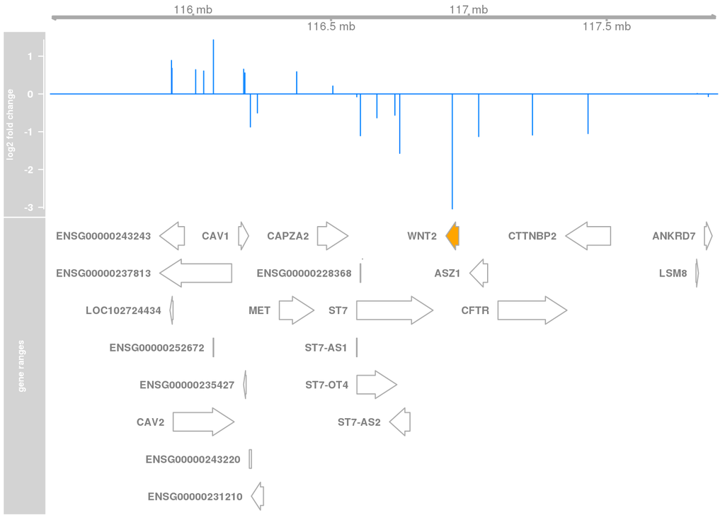

```r
options(ucscChromosomeNames = FALSE)
g <- GenomeAxisTrack()
a <- AnnotationTrack(resGRsub, name = "gene ranges", feature = status)
d <- DataTrack(resGRsub, data = "log2FoldChange", baseline = 0,
               type = "h", name = "log2 fold change", strand = "+")
plotTracks(list(g, d, a), groupAnnotation = "group",
           notsig = "white", sig = "orange")
```

参考文献： http://bioconductor.org/help/workflows/rnaseqGene/